# Twitter analysis

Last updated: 18 December 2019

This report is a brief exploratory Twitter analysis. Part 1 explores tweets mentioning @TraffordCouncil or the phrase “Trafford Council”. Part 2 examines the last 1,000 tweets sent by @TraffordCouncil.

### Part 1: tweets mentioning @TraffordCouncil or “Trafford Council”

There were 241 tweets - excluding retweets and replies - that mention [@TraffordCouncil](https://twitter.com/traffordcouncil) or include the phrase [“Trafford Council”](https://twitter.com/search?q=%22trafford%20council%22) between 08 and 17 December 2019. You can explore these tweets in an interactive table.

Word frequency

The most frequent word in tweets mentioning [@TraffordCouncil](https://twitter.com/traffordcouncil) or the phrase [“Trafford Council”](https://twitter.com/search?q=%22trafford%20council%22) was “vote” (27). This is unsurprising given the general election was held in the middle of the period examined on 12 December 2019. The prominence of terms such as “bins” (14) and “emptied” (12) suggests that bin collections were important concerns over the period too.

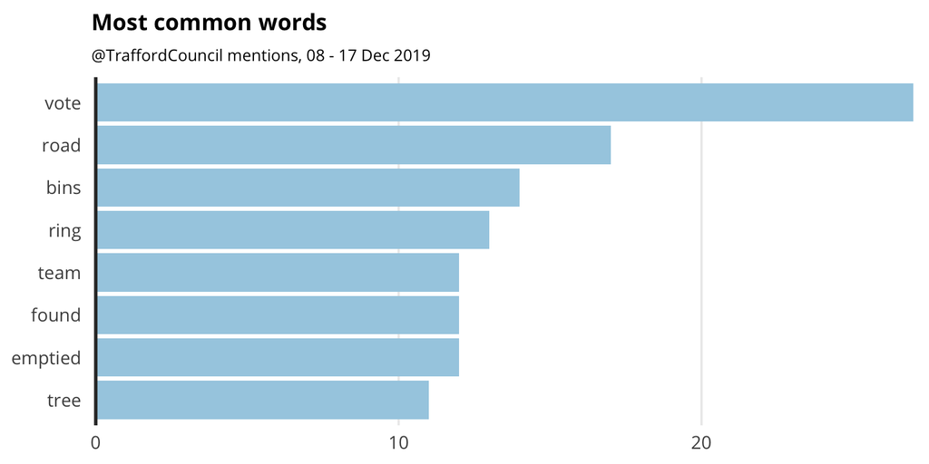

Hashtag frequency

The most commonly used hashtag over the period examined was [#ge2019](https://twitter.com/search?q=%23ge2019&src=typed_query), which refers to the 2019 General Election.

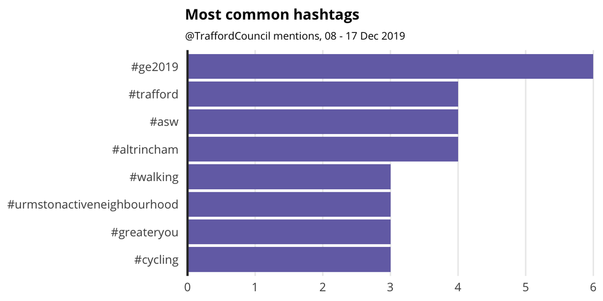

Sentiment analysis

Sentiment analysis is a type of text mining that assigns sentiment to text. Here the most common words in tweets mentioning [@TraffordCouncil](https://twitter.com/traffordcouncil) or [“Trafford Council”](https://twitter.com/search?q=%22trafford%20council%22) have been classified as either positive or negative. If we discount “hale” which refers to a ward we find positive sentiment in terms such as “love”, “beautiful” etc. Negative sentiment can be found in “drains” and “missed”. The term “marginal” is likely to refer to the General Election.

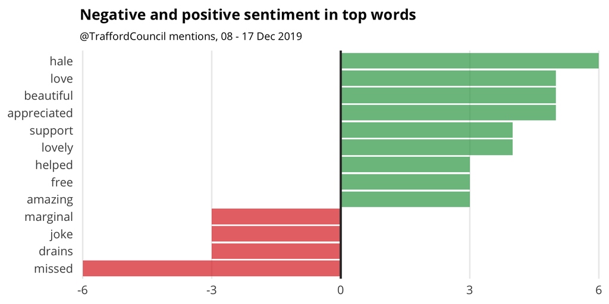

Network analysis

This network graph visualises the relationship between words in tweets that mentioned Trafford Council. The words “Trafford” and “Council” have the strongest relationship as indicated by the darker coloured arrow. Other linked words include “polling station”, “monkey puzzle” and “wedding ring found in ballot box”.

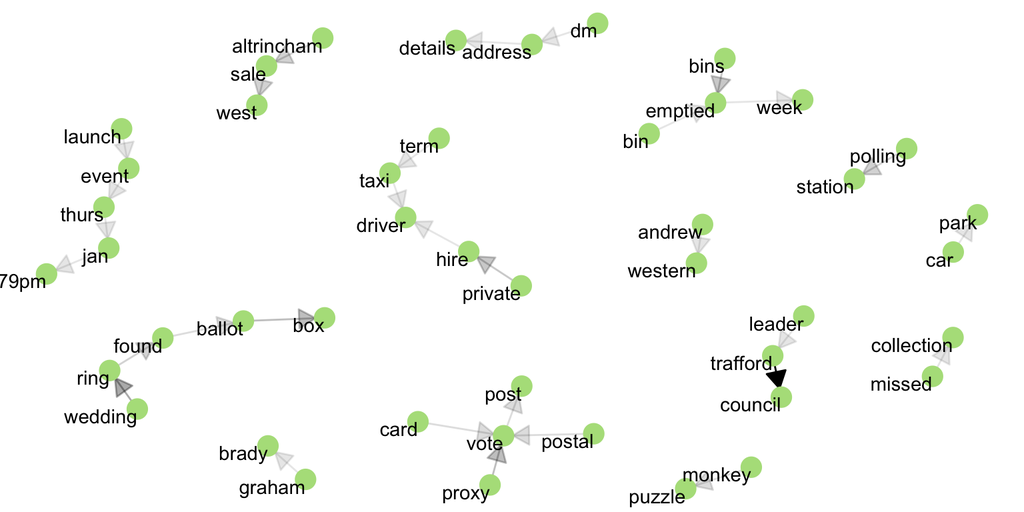

### Part 2: tweets by @TraffordCouncil

This section explores the last 1,000 tweets of [@TraffordCouncil](https://twitter.com/traffordcouncil) which cover the period between 18 August and 16 December 2019. You can explore these tweets in an interactive table.

Twitter activity

The bulk of [@TraffordCouncil](https://twitter.com/traffordcouncil)’s twitter activity occurs between 0700 and 1700 with a clear mid-afternoon peak.

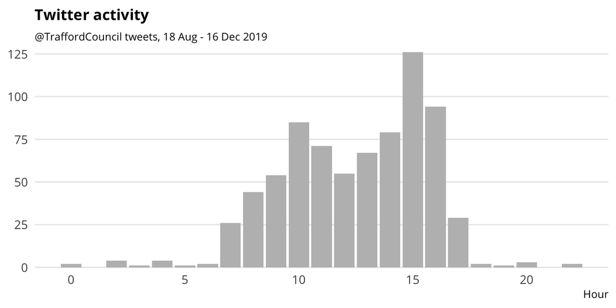

Word frequency

The most frequent terms tweeted from the [@TraffordCouncil](https://twitter.com/traffordcouncil) Twitter account were “people”, “day” and “free”.

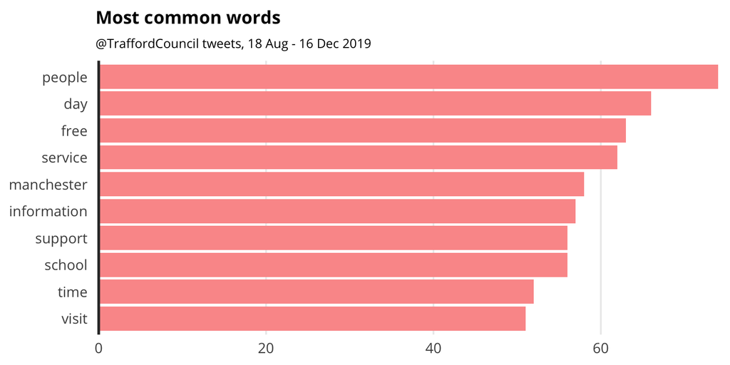

Most retweets

The most retweeted tweet from the [@TraffordCouncil](https://twitter.com/traffordcouncil) Twitter account was about the loss of a wedding ring in a ballot box. This tweet was retweeted 272 times. This tweet also received the most likes (149).

> We’ve found a wedding ring in one of our ballot boxes! It was found in the Cloverlea Primary School ballot box, Hale Barns. If it’s yours please call Access Trafford on 0161 912 2000 so we can reunite you with it!

> — Trafford Council (@TraffordCouncil) [December 13, 2019](https://twitter.com/TraffordCouncil/status/1205277494619844610)

Frequency of user mentions

[@OneTrafford](https://twitter.com/OneTrafford) was the most frequently mentioned Twitter account (28) by [@TraffordCouncil](https://twitter.com/TraffordCouncil).

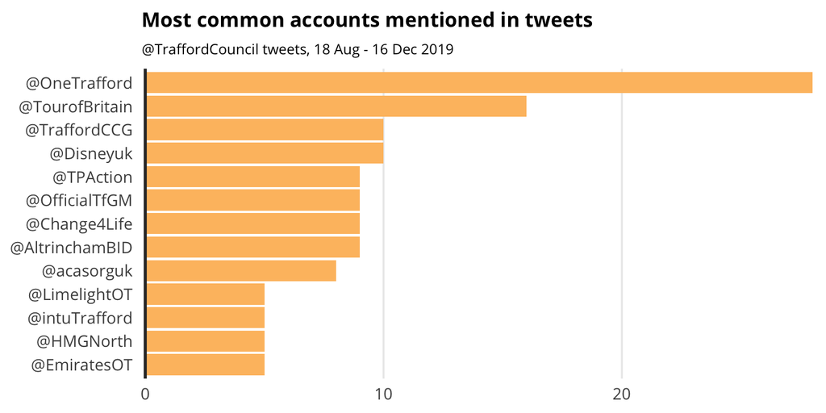

Likes by @TraffordCouncil

The Twitter account whose tweets were most frequently liked by [@TraffordCouncil](https://twitter.com/TraffordCouncil) was [@OneTrafford](https://twitter.com/OneTrafford) (50). You can explore all the tweets liked by @TraffordCouncil in an interactive table.

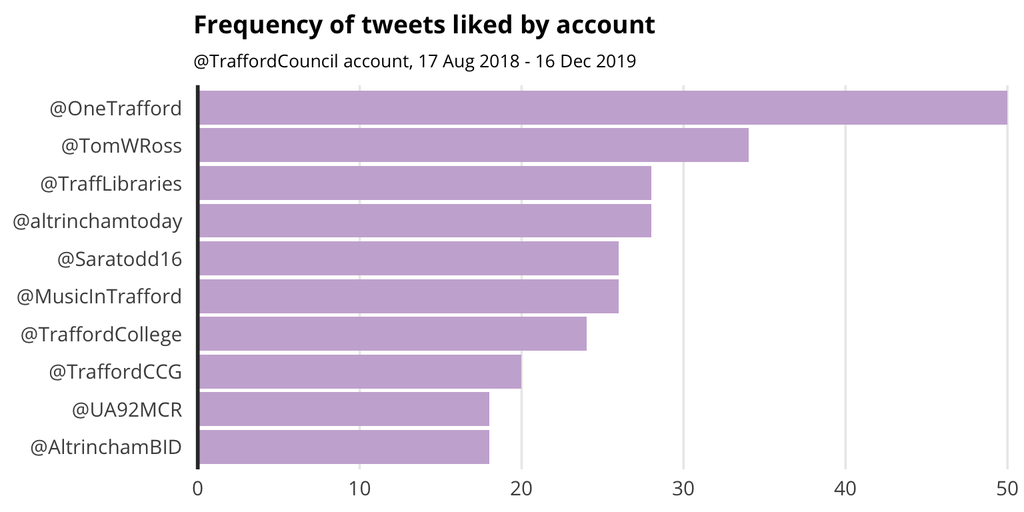

Credits: this analysis used the rtweet and tidytext [R](https://cran.r-project.org) packages.